# F.M.L. Assignment 2

Christine Donovan

2026-10-03

## Assignment 2: k-NN Classification for Universal Bank

This analysis uses k-nearest neighbors (k-NN) to predict whether a Universal Bank customer will accept a personal loan offer, based on customer demographic and account data.

# Load libraries

```r
library(class)
library(caret)
```

```r
library(ggplot2)
library(tidyr)
```

# Load the raw data UniversalBank.csv file

```r
bank<-read.csv("UniversalBank.csv")
```

# Convert Education to a factor

```r
bank$Education <- factor(bank$Education)
#Build and apply dummy-variable recipie
dummy_blueprint <- dummyVars(~ Education, data = bank)
Education_dummies <- predict(dummy_blueprint, newdata = bank)
```

```r
head(Education_dummies)
```

```
##   Education.1 Education.2 Education.3
## 1           1           0           0
## 2           1           0           0
## 3           1           0           0
## 4           0           1           0
## 5           0           1           0
## 6           0           1           0
```

# Bank and Education_dummies (with the three new ones) using cbind to combine into a single dataframe.

```r
bank_full<-cbind(bank, Education_dummies)
```

# Remove columns: Education, ID and Zip Code

```r
which(names(bank_full) %in% c("ID", "ZIP.Code", "Education"))
```

```
## [1] 1 5 8
```

```r
bank_full<- bank_full[ , -c(1, 5, 8)]
```

# Partioning the data training (60%) and the validation set(40% )

```r
set.seed(123)
train_index <- sample(1:nrow(bank_full), 0.60 * nrow(bank_full))
length(train_index)
```

```
## [1] 3000
```

```r
train_data <- bank_full[train_index, ]
nrow(train_data)
```

```
## [1] 3000
```

# Partioning the validation set (40%) All rows except the train_index

```r
validation_data<-bank_full[-train_index, ]
nrow(validation_data)
```

```
## [1] 2000
```

# Separate predictors from target variables before normalizing

```r
train_data_predictors <- train_data[ , -which(names(train_data) %in% c("Personal.Loan"))]
ncol(train_data_predictors)
```

```
## [1] 13
```

# Build and apply Normalization recipe

```r
norm_recipie <- preProcess(train_data_predictors, method = c("range"))
train_predictors <- predict(norm_recipie, newdata = train_data_predictors)
validation_predictors <- predict(norm_recipie, newdata = validation_data[ , -which(names(validation_data) %in% c("Personal.Loan"))])
summary(train_predictors)
```

```
##       Age           Experience         Income           Family
##  Min.   :0.0000   Min.   :0.0000   Min.   :0.0000   Min.   :0.0000
##  1st Qu.:0.2955   1st Qu.:0.2826   1st Qu.:0.1435   1st Qu.:0.0000
##  Median :0.5227   Median :0.5000   Median :0.2593   Median :0.3333
##  Mean   :0.5097   Mean   :0.5045   Mean   :0.3028   Mean   :0.4663
##  3rd Qu.:0.7273   3rd Qu.:0.7174   3rd Qu.:0.4028   3rd Qu.:1.0000
##  Max.   :1.0000   Max.   :1.0000   Max.   :1.0000   Max.   :1.0000
##      CCAvg           Mortgage       Securities.Account   CD.Account
##  Min.   :0.0000   Min.   :0.00000   Min.   :0.000      Min.   :0.000
##  1st Qu.:0.0700   1st Qu.:0.00000   1st Qu.:0.000      1st Qu.:0.000
##  Median :0.1500   Median :0.00000   Median :0.000      Median :0.000
##  Mean   :0.1924   Mean   :0.08707   Mean   :0.103      Mean   :0.059
##  3rd Qu.:0.2600   3rd Qu.:0.15433   3rd Qu.:0.000      3rd Qu.:0.000
##  Max.   :1.0000   Max.   :1.00000   Max.   :1.000      Max.   :1.000
##      Online         CreditCard      Education.1     Education.2
##  Min.   :0.0000   Min.   :0.0000   Min.   :0.000   Min.   :0.000
##  1st Qu.:0.0000   1st Qu.:0.0000   1st Qu.:0.000   1st Qu.:0.000
##  Median :1.0000   Median :0.0000   Median :0.000   Median :0.000
##  Mean   :0.5997   Mean   :0.2943   Mean   :0.424   Mean   :0.285
##  3rd Qu.:1.0000   3rd Qu.:1.0000   3rd Qu.:1.000   3rd Qu.:1.000
##  Max.   :1.0000   Max.   :1.0000   Max.   :1.000   Max.   :1.000
##   Education.3
##  Min.   :0.000
##  1st Qu.:0.000
##  Median :0.000
##  Mean   :0.291
##  3rd Qu.:1.000
##  Max.   :1.000
```

# Build and separate Label vectors

```r
train_labels <- factor(train_data$Personal.Loan)
validation_labels <- factor(validation_data$Personal.Loan)
```

```r
summary(train_predictors)
```

```
##       Age           Experience         Income           Family
##  Min.   :0.0000   Min.   :0.0000   Min.   :0.0000   Min.   :0.0000
##  1st Qu.:0.2955   1st Qu.:0.2826   1st Qu.:0.1435   1st Qu.:0.0000
##  Median :0.5227   Median :0.5000   Median :0.2593   Median :0.3333
##  Mean   :0.5097   Mean   :0.5045   Mean   :0.3028   Mean   :0.4663
##  3rd Qu.:0.7273   3rd Qu.:0.7174   3rd Qu.:0.4028   3rd Qu.:1.0000
##  Max.   :1.0000   Max.   :1.0000   Max.   :1.0000   Max.   :1.0000
##      CCAvg           Mortgage       Securities.Account   CD.Account
##  Min.   :0.0000   Min.   :0.00000   Min.   :0.000      Min.   :0.000
##  1st Qu.:0.0700   1st Qu.:0.00000   1st Qu.:0.000      1st Qu.:0.000
##  Median :0.1500   Median :0.00000   Median :0.000      Median :0.000
##  Mean   :0.1924   Mean   :0.08707   Mean   :0.103      Mean   :0.059
##  3rd Qu.:0.2600   3rd Qu.:0.15433   3rd Qu.:0.000      3rd Qu.:0.000
##  Max.   :1.0000   Max.   :1.00000   Max.   :1.000      Max.   :1.000
##      Online         CreditCard      Education.1     Education.2
##  Min.   :0.0000   Min.   :0.0000   Min.   :0.000   Min.   :0.000
##  1st Qu.:0.0000   1st Qu.:0.0000   1st Qu.:0.000   1st Qu.:0.000
##  Median :1.0000   Median :0.0000   Median :0.000   Median :0.000
##  Mean   :0.5997   Mean   :0.2943   Mean   :0.424   Mean   :0.285
##  3rd Qu.:1.0000   3rd Qu.:1.0000   3rd Qu.:1.000   3rd Qu.:1.000
##  Max.   :1.0000   Max.   :1.0000   Max.   :1.000   Max.   :1.000
##   Education.3
##  Min.   :0.000
##  1st Qu.:0.000
##  Median :0.000
##  Mean   :0.291
##  3rd Qu.:1.000
##  Max.   :1.000
```

```r
train_data_predictors <- train_data[ , -which(names(train_data) %in% c("Personal.Loan"))]
ncol(train_data_predictors)
```

```
## [1] 13
```

# Build data frame for new customer and normalize it

```r
new_customer_q1 <- data.frame(
  Age = 40,
  Experience = 10,
  Income = 84,
  Family = 2,
  CCAvg = 2,
  Mortgage = 0,
  Securities.Account = 0,
  CD.Account = 0,
  Online = 1,
  CreditCard = 1,
  Education.1 = 0,
  Education.2 = 1,
  Education.3 = 0
)
```

```r
new_customer_q1
```

```
##   Age Experience Income Family CCAvg Mortgage Securities.Account CD.Account
## 1  40         10     84      2     2        0                  0          0
##   Online CreditCard Education.1 Education.2 Education.3
## 1      1          1           0           1           0
```

# Normalize new customer

```r
new_customer_norm <- predict(norm_recipie, newdata = new_customer_q1)
new_customer_norm
```

```
##         Age Experience    Income    Family CCAvg Mortgage Securities.Account
## 1 0.3863636  0.2826087 0.3518519 0.3333333   0.2        0                  0
##   CD.Account Online CreditCard Education.1 Education.2 Education.3
## 1          0      1          1           0           1           0
```

# Problem 1: Run k-NN with k=1. The classification result (0, not accepted)

```r
knn_result_q1 <- knn(train = train_predictors, test = new_customer_norm, cl = train_labels, k = 1)
knn_result_q1
```

```
## [1] 0
## Levels: 0 1
```

# Problem 2. Step 1: Rebuild a combined training datafame (normalized predictors + labels) & run check

```r
train_knn_data <- data.frame(train_predictors, Personal.Loan = train_labels)
str(train_knn_data)
```

```
## 'data.frame':    3000 obs. of  14 variables:
##  $ Age               : num  0.6591 0.8864 0.0455 0.9318 0.9773 ...
##  $ Experience        : num  0.674 0.891 0.087 0.891 0.978 ...
##  $ Income            : num  0.0694 0.2037 0.4167 0.3287 0.4028 ...
##  $ Family            : num  0.667 1 0 0.333 0.333 ...
##  $ CCAvg             : num  0.04 0.13 0.54 0.28 0 0.36 0.01 0.29 0.09 0.15 ...
##  $ Mortgage          : num  0 0 0 0.282 0 ...
##  $ Securities.Account: num  0 0 0 0 0 0 0 0 1 0 ...
##  $ CD.Account        : num  0 0 0 0 0 0 0 0 0 0 ...
##  $ Online            : num  1 1 1 0 1 0 1 1 1 0 ...
##  $ CreditCard        : num  0 1 0 0 0 0 1 0 0 1 ...
##  $ Education.1       : num  1 0 1 1 0 0 0 0 0 0 ...
##  $ Education.2       : num  0 1 0 0 0 0 1 0 0 1 ...
##  $ Education.3       : num  0 0 0 0 1 1 0 1 1 0 ...
##  $ Personal.Loan     : Factor w/ 2 levels "0","1": 1 1 1 1 1 1 1 2 1 1 ...
```

# Step 2. Set up train() to search for the best K.

```r
Personal.Loan ~.
```

```
## Personal.Loan ~ .
```

```r
knn_tune <- train(Personal.Loan ~ ., data = train_knn_data, method = "knn", tuneGrid = expand.grid(k = 1:20))
knn_tune
```

```
## k-Nearest Neighbors
##
## 3000 samples
##   13 predictor
##    2 classes: '0', '1'
##
## No pre-processing
## Resampling: Bootstrapped (25 reps)
## Summary of sample sizes: 3000, 3000, 3000, 3000, 3000, 3000, ...
## Resampling results across tuning parameters:
##
##   k   Accuracy   Kappa
##    1  0.9523785  0.6838790
##    2  0.9496375  0.6579394
##    3  0.9490091  0.6442402
##    4  0.9470101  0.6232175
##    5  0.9474964  0.6171187
##    6  0.9455964  0.5962091
##    7  0.9457467  0.5922486
##    8  0.9441096  0.5750810
##    9  0.9432754  0.5645698
##   10  0.9411579  0.5437132
##   11  0.9406431  0.5372014
##   12  0.9393406  0.5224839
##   13  0.9389287  0.5155935
##   14  0.9373694  0.4989574
##   15  0.9356978  0.4806254
##   16  0.9346803  0.4702331
##   17  0.9342495  0.4649525
##   18  0.9332643  0.4527168
##   19  0.9318786  0.4386231
##   20  0.9320203  0.4375610
##
## Accuracy was used to select the optimal model using the largest value.
## The final value used for the model was k = 1.
```

# Ggplot Observation

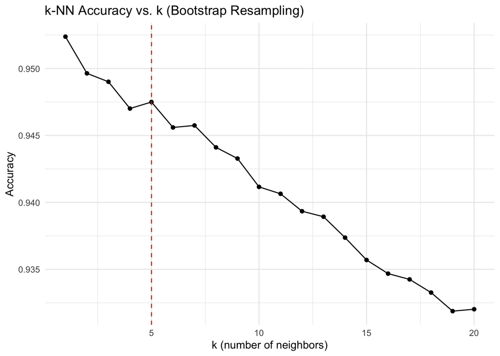

```r
ggplot(knn_tune$results, aes(x = k, y = Accuracy)) +
  geom_line() +
  geom_point() +
  geom_vline(xintercept = 5, linetype = "dashed", color = "red") +
  labs(title = "k-NN Accuracy vs. k (Bootstrap Resampling)",
       x = "k (number of neighbors)",
       y = "Accuracy") +
  theme_minimal()
```